# Student Performance

# Trees

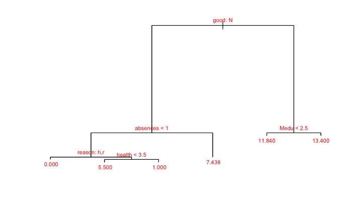

```r
set.seed(3)
tree.stud <- tree(G3 ~ ., train_stud)
plot(tree.stud)
text(tree.stud, pretty = 1, cex=0.7, col='red')
```

```r
#print(tree.stud)
```

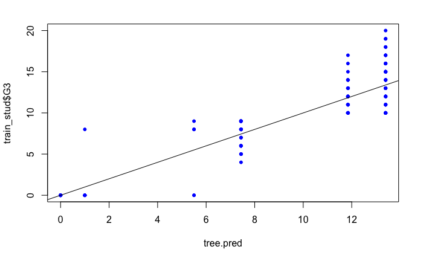

```r
tree.pred <- predict(tree.stud, train_stud)
plot(tree.pred,train_stud$G3, pch = 20, col= 'blue')
abline(a=0,b=1)
```

### Pruning the Trees

```r
set.seed(3)
cv.stud <- cv.tree(tree.stud, FUN = prune.tree)
cv.stud
```

```
$size
[1] 6 4 3 2 1

$dev
[1] 1344.956 1268.725 1239.748 1837.674 4336.145

$k
[1]       -Inf   62.42308   68.82404  579.24675 2564.99722

$method
[1] "deviance"

attr(,"class")
[1] "prune"         "tree.sequence"
```

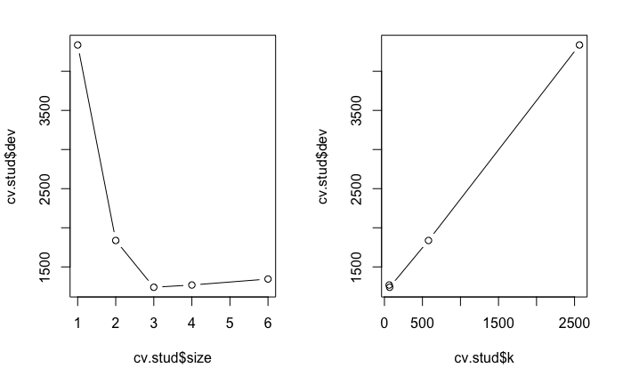

```r
par(mfrow = c(1, 2))
plot(cv.stud$size, cv.stud$dev, type = "b")
plot(cv.stud$k, cv.stud$dev, type = "b")
```

```r
# From the above plot, we can see that the best performing tree would be at the size=3
```

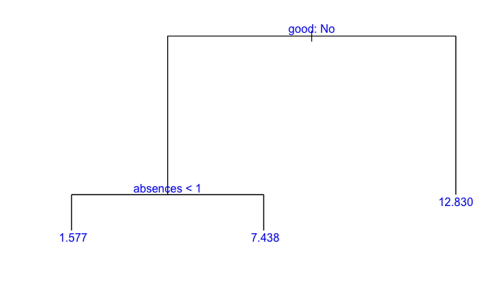

```r
#So, implementing tree for the best best size
prune.stud <- prune.tree(tree.stud, best = 3)
plot(prune.stud)
text(prune.stud, pretty = 0, col = 'blue')
```

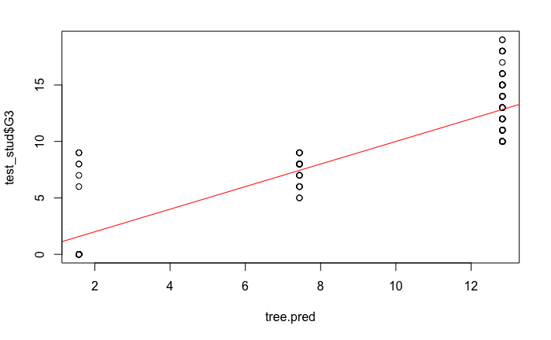

```r
#Evaluating the performance on our test dataset
tree.pred <- predict(prune.stud, test_stud)
plot(tree.pred,test_stud$G3)
abline(a=0,b=1, col= 'red')
```

```r
mean_prune <- mean((tree.pred-test_stud$G3)^2)
mean_prune
```

```
[1] 6.296286
```

```r
#mean squared error on test data is worse than the train data in pruning tree
```

[output not shown]

### Random Forest

```r
#bagging
set.seed(5)
bag_tree = randomForest(G3 ~ ., data = train_stud, mtry=24, importance =TRUE)

plot(bag_tree$mse, xlab="N Trees", ylab="MSE", ylim=c(0,12),type='l')
# random forest
rf_tree = randomForest(G3 ~ ., data = train_stud, mtry=5, importance =TRUE)
lines(rf_tree$mse,col='green')
```

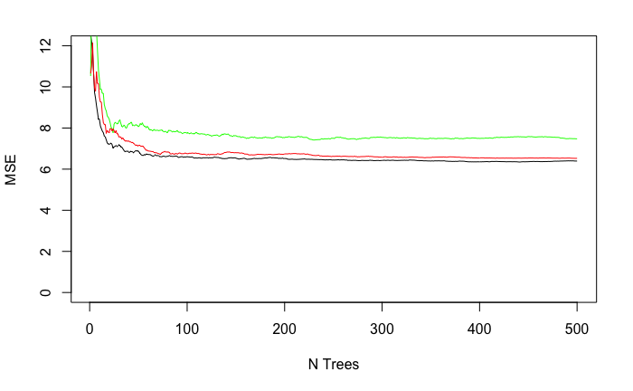

```r
rf_tree = randomForest(G3 ~ ., data = train_stud, mtry=13, importance =TRUE)
lines(rf_tree$mse,col='red')
```

```r
pred_rf <- predict(rf_tree, newdata = test_stud)
mean_rf_tree <- mean((pred_rf-test_stud$G3)^2)
mean_rf_tree
```

```
[1] 6.498735
```

```r
#we calculated the mse for the test data on random forest tree
# rf_tree$mse stores the MSE calculated on the Out-Of-Bag
```

[output not shown]

## Summary

In this report, the student performance dataset was used so that I can predict the various factors which may lead to a change in performance in the score of the students. I applied various models in this dataset to understand how various predictors are correlated with each other and how they affect the student’s performance.

This report is developed on ‘R’ using the various libraries and functions of the R language. I first analyzed the current score by plotting the score data in a histogram.

First, a linear regression was performed using stepwise selection to generate the best performing models that have different types of predictors.

Second, Decision Tree fitting was performed on the dataset. Pruning method and the random forest method was performed.